# BuckalewJessup 591 Part 3

Duke Buckalew

2025-11-11

# 1 Read in the Data

```r
train_data = readRDS("FINALTrainingBuckalewJessup4.RDS")
holdout_data = readRDS("FINALHoldoutBuckalewJessup4.RDS")
pred.holdout = readRDS("pred.holdout_final.rds")
```

# 2 Fit Logistic Regression

```r
#First we set up a 'traincontrol' object. We are using 10 fold cross validation. We will use this to select the lasso parameter.
ctrl <- trainControl(method = "cv", number = 10,
                     summaryFunction = twoClassSummary,
                     classProbs = TRUE,
                     savePredictions = "final")

#Next we fit our logistic regression model using an elastic net approach to regularization.

logit_fit <- train(
  loan_default ~ .,
  data = train_data,
  method = "glmnet",
  trControl = ctrl,
  tuneGrid = expand.grid(alpha = .11111, lambda = .0001),
  metric = "ROC",
  family = "binomial"
)
```

Through original analysis, we found that our best alpha for this model was .11111 and our lambda was .0001. To save time and processing power, that will be inputted here.

```r
logit_fit$results
```

|  | alpha | lambda | ROC | Sens | Spec | ROCSD | SensSD | SpecSD |
| --- | --- | --- | --- | --- | --- | --- | --- | --- |
| 1 | 0.11111 | 1e-04 | 0.8437986 | 0.7731383 | 0.7726242 | 0.003564242 | 0.007059802 | 0.007614287 |

Here we can see our model has a ROC AUC of .844, which falls within the general strength of our models so far and is to be expected.

# 3 Predict on Holdout

```r
#Make predictions on Holdout
pred.holdout$logistic.prob <- predict(logit_fit,
                           newdata = holdout_data,
                           type = "prob")[,"Yes"]
pred.holdout$logistic.class<- factor(ifelse(pred.holdout$logistic.prob > 0.5,
                                      "Yes","No"),
                               levels=c("Yes","No"))
```

Here we use a threshold of 0.5, but this might not be the most optimal. Because of this, we will find 2 more thresholds and compare their performances, ultimately deciding on one to save.

# 4 Threshold Optimization

```r
# finding our optimal threshold through youden's j
predlogistic <- prediction(pred.holdout$logistic.prob, pred.holdout$loan_default)
perflogistic <- performance(predlogistic, "tpr", "fpr")
tpr <- perflogistic@y.values[[1]]
fpr <- perflogistic@x.values[[1]]
thresholds <- perflogistic@alpha.values[[1]]

youden_j <- tpr - fpr

optimal_index <- which.max(youden_j)
optimal_threshold <- thresholds[optimal_index]

predlogistic_class_j <- ifelse(pred.holdout$logistic.prob >= optimal_threshold, "Yes", "No")
predlogistic_class_j <- factor(predlogistic_class_j, levels = levels(pred.holdout$loan_default))
```

Our optimal youden’s j threshold is .5154819, which means our model is moderately good at accurately identifying positives and negatives.

```r
perf_f1 <- performance(predlogistic, measure = "f")
f1_values <- perf_f1@y.values[[1]]
f1_thresholds <- perf_f1@x.values[[1]]

# Find best F1 threshold
optimal_f1_index <- which.max(f1_values)
optimal_f1_threshold <- f1_thresholds[optimal_f1_index]

predlogistic_class_f1 <- ifelse(pred.holdout$logistic.prob >= optimal_f1_threshold, "Yes", "No")
predlogistic_class_f1 <- factor(predlogistic_class_f1, levels = c("No","Yes"))

cm_f1 <- confusionMatrix(predlogistic_class_f1, pred.holdout$loan_default, positive="Yes")
cm_j  <- confusionMatrix(predlogistic_class_j,  pred.holdout$loan_default, positive="Yes")

results <- data.frame(
  Cutoff = c("Optimal F1", "Optimal Youden's J"),
  Sensitivity = c(cm_f1$byClass["Sensitivity"], cm_j$byClass["Sensitivity"]),
  Specificity = c(cm_f1$byClass["Specificity"], cm_j$byClass["Specificity"]),
  Precision   = c(cm_f1$byClass["Pos Pred Value"], cm_j$byClass["Pos Pred Value"]),
  F1_Score    = c(cm_f1$byClass["F1"], cm_j$byClass["F1"])
)

results
```

| Cutoff | Sensitivity | Specificity | Precision | F1_Score |
| --- | --- | --- | --- | --- |
| Optimal F1 | 0.6452609 | 0.8641723 | 0.5368596 | 0.5860900 |
| Optimal Youden's J | 0.7575446 | 0.7823397 | 0.4592370 | 0.5718241 |

Conversely, our optimal F1 threshold is .652355. This is a distinct difference from our youden’s j threshold, meaning the difference is anything but negligable. Because of this it is necessary to compare their metrics. Here we can see our F1 threshold has a higher specificity, precision, and F1 score. It is because of this that we will ultimately end up using this threshold instead of our youden’s j.

# 5 AUC

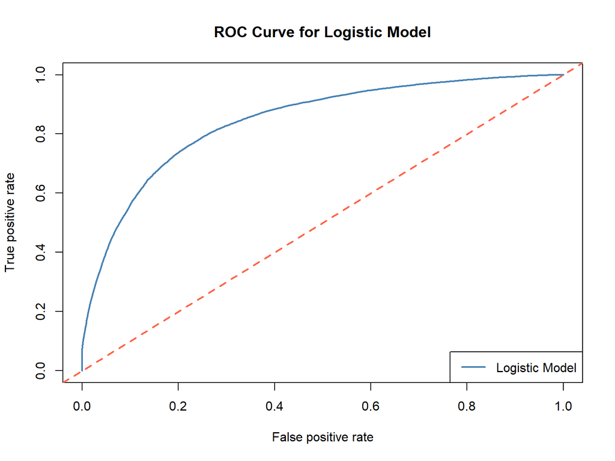

```r
plot(perflogistic, col = "steelblue", lwd = 2, main = "ROC Curve for Logistic Model")
abline(a = 0, b = 1, col = "tomato", lty = 2, lwd = 2)

legend("bottomright",
       legend=c("Logistic Model"),
       col=c("steelblue"), lwd=2)
```

```r
# Extract AUC
auc <- performance(predlogistic, "auc")@y.values[[1]]
```

Here we can see our AUC visualized.

```r
pred.holdout$predlogistic_class_f1 = predlogistic_class_f1
saveRDS(pred.holdout, "pred.holdout.rds")
```